# Workflow

Dr Jeremiah MF Kelly

2016-06-02

The following describes the work flow for the analysis of dark adaptation data. The data were extracted from Figure 1 in Rushton’s paradox: rod dark adaptation after flash photolysis, E.N.Pugh Jr. 1975.

A ‘dark’ object can have up to 16 elements and no fewer than 2.

```r
library(Dark)
tmp <- dark
names(tmp)
```

```
##  [1] "time"      "thrs"      "fit"       "resid"     "R2"
##  [6] "Bootstrap" "weight"    "valid"     "Mod"       "Pn"
## [11] "AIC"       "data"      "opt"       "call"      "val"
```

The raw data are shown below

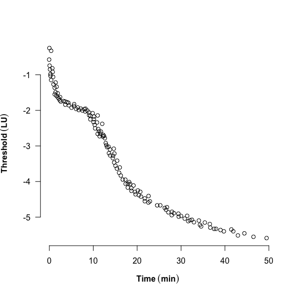

```r
par(las=1, bty='n',mfrow=c(1,1))
XL <- expression(bold(Time~(min)))
YL <- expression(bold(Threshold~(LU)))
plot(tmp$time, tmp$thrs, xlab = XL, ylab=YL)
```

The function `Start` generates an array of possible parameter values, *P*, calculated from the data, which are then passed to `ModelSelect`.

```r
set.seed(1234)
P <-Start(tmp, 2000)
head(P,3)
```

The first three rows are shown below

```
##           CT      CC     Tau      S2    Alph      S3    Beta
## [1,] -1.9305  0.2536  3.9765 -0.3899  2.5221  0.1306 32.5607
## [2,] -0.9662  0.4203  0.7632 -0.4064  6.9688  0.2074 32.9920
## [3,] -0.9909  1.3296  0.9057 -0.1825  3.1220  0.0885 29.4212
```

The data frame `P` is processed by `ModelSelect`, this finds the row of parameters that give the lowest sum of squared errors and calculates an `AIC` score. This is not calculated again.

```r
MSC<-ModelSelect(tmp,P)
MSC
```

```
## $AIC
## [1]    0    0 -348    0 -353 -556 -562
##
## $param
##       [,1] [,2]   [,3]    [,4] [,5]   [,6] [,7]
## [1,] -7.04 6.23 28.121  0.0000 0.00 0.0000  0.0
## [2,] -4.85 4.02 17.225 -0.0366 9.40 0.0000  0.0
## [3,] -5.53 1.43  0.558  9.6192 3.50 0.0972  0.0
## [4,] -1.97 1.40  1.623 -0.2279 8.74 0.1808 19.4
```

Then the function `BestFit` optimises the model using the lowest `AIC` score to select the model and the best initial estimate of the parameters for that model.

```r
tmp<-BestFit(tmp,MSC)
```

A further function `MultiStart` ensures that the estimated parameter values are optimal by repeatedly optimising the model with starting locations in the vicinity of the initial estimate. Finally `BootDark` uses bootstrap methods to calculate confidence intervals for the parameter estimates.

```r
tmp<-MultiStart(tmp,repeats = 25)
tmp<-BootDark(tmp,R = 500)
```

The data and model are shown in the figure below;

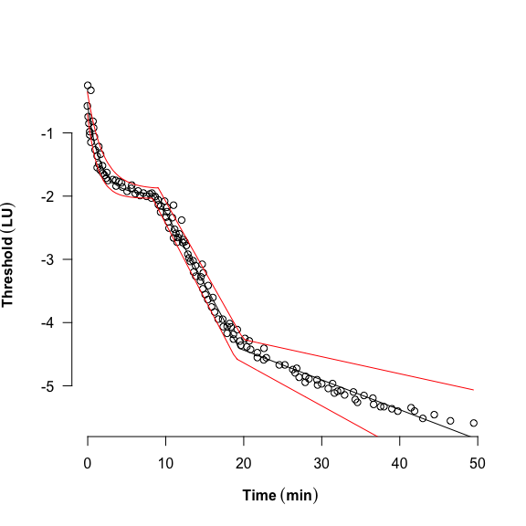

The final `dark` object with 15 elements:

```r
print(tmp,2)
```

```
## $time
##   [1] -0.0494  0.0014  0.0521  0.1503  0.2518  0.2518  0.4022  0.4040
##   [9]  0.6788  0.7541  0.8574  0.9423  1.2075  1.2109  1.4087  1.4202
##  [17]  1.5907  1.6476  1.8917  1.9293  2.1700  2.3712  2.4448  2.5970
##  [25]  3.2045  3.5825  3.6315  4.0226  4.3369  4.4499  5.0504  5.5658
##  [33]  5.6409  6.0925  6.4575  6.7097  7.1385  7.5279  7.9567  8.1581
##  [41]  8.2332  8.6490  9.0288  9.0550  9.3430  9.3577  9.8603 10.0694
##  [49] 10.1447 10.1560 10.3329 10.4229 10.8483 11.0006 11.0006 11.1398
##  [57] 11.3017 11.4558 11.5931 11.7436 12.0412 12.1724 12.2836 12.4508
##  [65] 12.6389 12.8401 12.9775 13.1544 13.5062 13.5683 13.8187 13.8466
##  [73] 14.4584 14.5092 14.6729 14.7596 14.8137 15.0607 15.3880 15.4370
##  [81] 15.8789 16.0408 16.2700 16.7234 17.3011 17.3747 17.8655 17.8788
##  [89] 18.1833 18.3715 18.6708 18.6821 19.1750 19.5118 19.6248 20.1551
##  [97] 20.3958 20.7100 20.8735 21.7427 21.7427 22.5593 22.5967 22.8979
## [105] 24.5538 25.2689 26.2867 26.5879 26.7891 27.1033 27.8822 27.9199
## [113] 28.3618 29.3911 29.4664 29.9950 30.8361 31.3875 31.6263 32.0159
## [121] 32.4691 32.9322 34.0630 34.3019 34.5785 35.4178 36.5502 36.6517
## [129] 37.5339 37.9743 38.9938 39.7500 41.4565 41.8986 42.9541 44.4235
## [137] 46.4952 49.4832
##
## $thrs
##   [1] -0.57 -0.25 -0.74 -0.85 -0.98 -1.03 -0.33 -1.15 -0.82 -0.92 -1.06
##  [12] -1.27 -1.37 -1.55 -1.49 -1.22 -1.59 -1.34 -1.52 -1.64 -1.67 -1.72
##  [23] -1.63 -1.75 -1.74 -1.75 -1.84 -1.77 -1.79 -1.86 -1.92 -1.88 -1.83
##  [34] -1.96 -1.92 -1.99 -1.95 -2.00 -1.97 -2.03 -1.95 -2.01 -2.06 -2.14
##  [45] -2.25 -2.15 -2.08 -2.33 -2.25 -2.18 -2.41 -2.51 -2.34 -2.14 -2.66
##  [56] -2.52 -2.59 -2.73 -2.65 -2.60 -2.38 -2.73 -2.69 -2.72 -2.78 -2.92
##  [67] -2.98 -3.03 -3.02 -3.20 -3.10 -3.27 -3.34 -3.28 -3.08 -3.47 -3.21
##  [78] -3.56 -3.64 -3.41 -3.75 -3.60 -3.83 -3.94 -3.95 -4.06 -4.17 -4.06
##  [89] -4.02 -4.07 -4.19 -4.26 -4.11 -4.29 -4.36 -4.25 -4.38 -4.29 -4.42
## [100] -4.48 -4.55 -4.59 -4.41 -4.56 -4.67 -4.67 -4.74 -4.80 -4.72 -4.87
## [111] -4.95 -4.85 -4.89 -4.90 -4.99 -4.97 -5.04 -4.96 -5.11 -5.09 -5.08
## [122] -5.14 -5.10 -5.22 -5.26 -5.15 -5.19 -5.29 -5.33 -5.33 -5.36 -5.40
## [133] -5.35 -5.40 -5.52 -5.46 -5.55 -5.59
##
## $fit
##   [1] -0.53 -0.58 -0.62 -0.70 -0.78 -0.78 -0.88 -0.88 -1.05 -1.10 -1.15
##  [12] -1.19 -1.31 -1.31 -1.39 -1.39 -1.45 -1.47 -1.54 -1.55 -1.61 -1.65
##  [23] -1.66 -1.69 -1.78 -1.82 -1.82 -1.85 -1.87 -1.88 -1.91 -1.92 -1.92
##  [34] -1.94 -1.94 -1.95 -1.95 -1.95 -1.96 -1.96 -1.96 -1.96 -2.04 -2.04
```

[output cut: 60 more lines]

```
##
## $opt
## [1] -1.97  1.39  1.61 -0.23  8.70  0.18 19.43
##
## $val
## [1] 2.1
##
## $call
## BootDark(obj = tmp, R = 500, graph = T)
##
## $data
## [1] "Pugh_1975"
##
## attr(,"class")
## [1] "dark"
```